# Search results bibliography screening: Title and abstract

Andrew Habrich

2023-03-14

Click figures to zoom in. The document works best on Chrome or Firefox. You can also download the .RMD file by clicking on the button at the top-right corner of the web page.  
Document made with R version 4.2.2

### 1. Required R packages

```r
## install.packages("tidyverse","metagear","rcrossref) install packages as needed
library(plyr) #plyr needs to be loaded BEFORE tidyverse to prevent issues with dplyr
library(tidyverse) #load tidyverse
library(synthesisr) #import bibliographic data - part of metaverse
library(lubridate) #this should be in the tidyverse, if for some reason it isn't you can install it seperately
library(metagear) #abstract/title screening package
library(rcrossref) #interface with 'crossref' api
```

### 2. Read in the deduplicated bibliographic data set

```r
initial_dat <-
  read_refs(filename = "./output/deduplicated_bib_02-1.ris", return_df = T)
```

Let’s check the structure and clean the data so that we can systematically screen

There are **16** columns. As you can see from the table below, they are all coded as ‘character’, even the year.

```
## # A tibble: 16 × 2
##    colname     classes
##    <chr>       <chr>
##  1 source_type character
##  2 author      character
##  3 year        character
##  4 title       character
##  5 journal     character
##  6 volume      character
##  7 issue       character
##  8 start_page  character
##  9 end_page    character
## 10 abstract    character
## 11 doi         character
## 12 url         character
## 13 publisher   character
## 14 notes       character
## 15 source      character
## 16 keywords    character
```

#### 2.1. Data cleaning and exploration

How many NAs are there in the dataframe columns?

```
## # A tibble: 16 × 2
##    Column      `# of NAs`
##    <chr>            <int>
##  1 source_type          0
##  2 author              33
##  3 year                 6
##  4 title                0
##  5 journal           1409
##  6 volume            1146
##  7 issue             1560
##  8 start_page         427
##  9 end_page          1571
## 10 abstract           108
## 11 doi                682
## 12 url                136
## 13 publisher         1390
## 14 notes             2183
## 15 source            2174
## 16 keywords          2304
```

A number of other data cleaning steps are done too; The descriptive steps taken are in script 03-screening_metagear available on [my GitHub page by clicking here](https://github.com/drewhabrich/MetaUrbanConn).

### 3. Bibliography data exploration

Let’s take a peek at the first couple of rows:

```r
#Check the data structure
head(dat)
```

```
## # A tibble: 6 × 14
##   source_t…¹ author  year title journal volume issue start…²
##   <chr>      <chr>  <dbl> <chr> <chr>   <chr>  <chr> <chr>
## 1 JOUR       Abrah…  2017 Does… Journa… 54     2     412
## 2 JOUR       Adams…  2017 Taki… Oryx    51     2     347
## 3 JOUR       Barba…  2020 Impa… Procee… 117    7     3648
## 4 JOUR       Braak…  2014 Habi… Ecology 95     4     1010
## 5 JOUR       Belot…  2020 Deli… Conser… 2      6     <NA>
## 6 JOUR       Casti…  2020 Conn… Land    9      8     239
## # … with 6 more variables: end_page <chr>, abstract <chr>,
## #   doi <chr>, url <chr>, publisher <chr>, source <chr>,
## #   and abbreviated variable names ¹source_type,
## #   ²start_page
```

#### Let’s think about some data exploration questions to get familiar with the data

##### 3.1 How many publications per year are there on this topic?

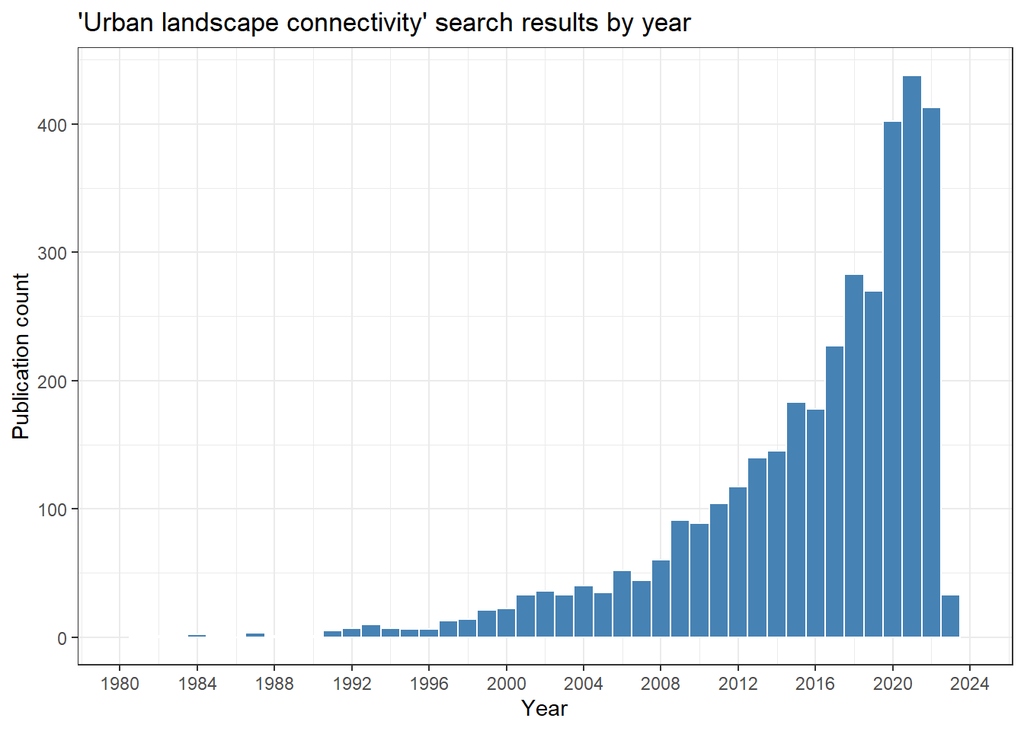

##### 3.2 How many authors/articles are there?

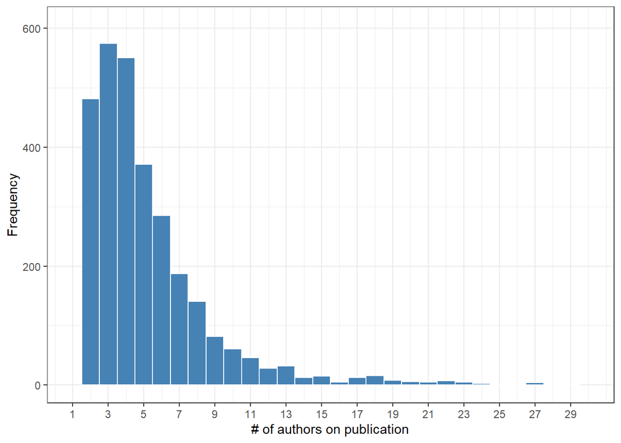

**Zero single authored papers!**

##### 3.3 How many different journals are the entries published in? (NOTE: Some entries do not have a journal; i.e. preprint, thesis, or non-peer reviewed articles)

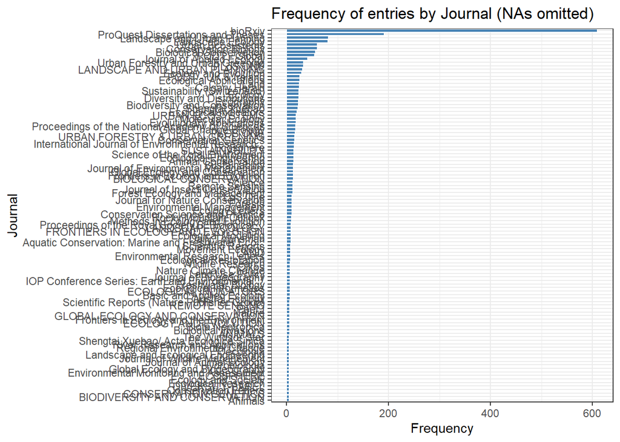

Note how some journals appear multiple times (in all upper-case or title-case). Have to fix this for later plots.

### 4. Title and abstract screening using the MetaGear package v.0.7

#### 4.1 Screening effort summary

Summary of screening, grouped by decision category

| Decision | n | % total | Description |
| --- | --- | --- | --- |
| TitleExcl | 1635 | 46.0 | Excluded based title, no indication of ‘urban’ or ‘landscape connectivity’ |
| AbstrExcl | 695 | 19.0 | Excluded based on abstract, not urban or no measure of connectivity |
| MAYBE | 610 | 17.0 | Unclear eligibility, needs full text screening |
| YES | 331 | 9.3 | Potential candidate studies identified |
| REVIEW | 299 | 8.4 | Review/Methodology/Framework articles |

#### 4.2 For articles coded as ‘YES’ (for full text screening), what journals are they in?

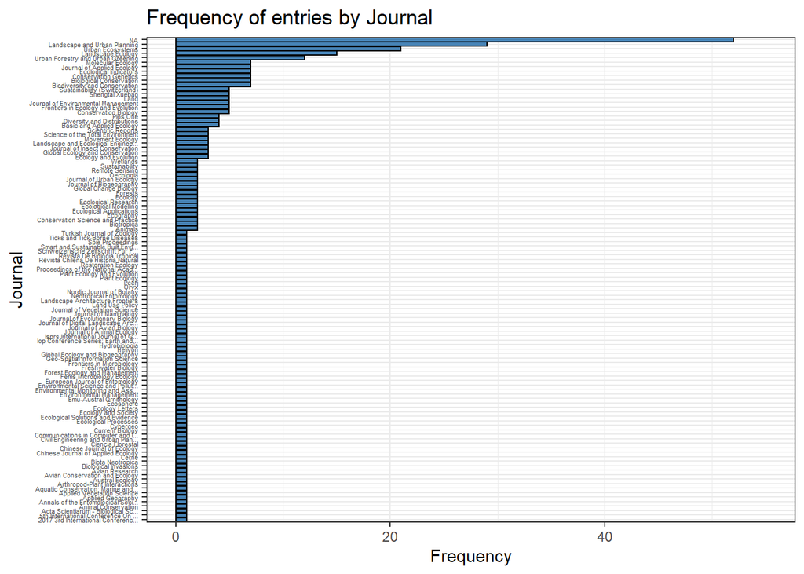

#### 4.3 For journals with >5 entries, what is the breakdown by each decision group?

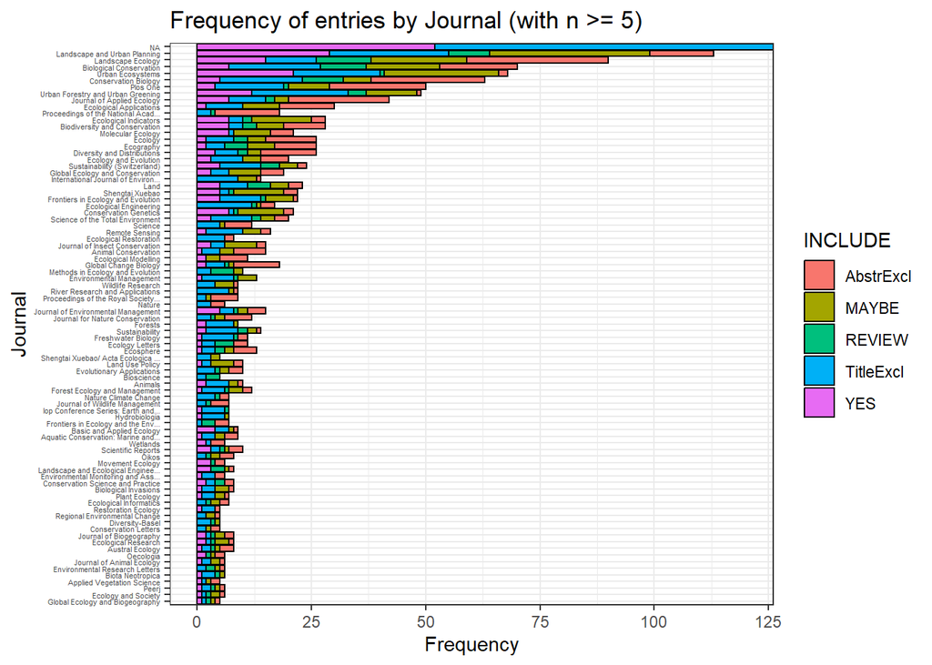

### 5. Next steps

Several issues still need to be resolved before moving on to data extraction:  
- Full-text reading for all the ‘MAYBE’s  
- Full-text download for all the potential candidate studies  
- Chase citations from key reviews in the ’REVIEW’ group

For data extraction:  
- Put together team of people to help flag and extract data  
- Create extraction sheet and instructions/meta-data for extractions